# Superbowl Ads

This week’s data is on Superbowl advertisements.

```r
library(tidyverse)
sb <- readr::read_csv('https://raw.githubusercontent.com/rfordatascience/tidytuesday/master/data/2021/2021-03-02/youtube.csv')
```

```r
skimr::skim(sb)
```

```
-- Data Summary ------------------------
                           Values
Name                       sb
Number of rows             247
Number of columns          25
_______________________
Column type frequency:
  character                10
  logical                  7
  numeric                  7
  POSIXct                  1
________________________
Group variables            None

-- Variable type: character -------------------------------------------------------
# A tibble: 10 x 8
   skim_variable             n_missing complete_rate   min   max empty n_unique
 * <chr>                         <int>         <dbl> <int> <int> <int>    <int>
 1 brand                             0         1         3     9     0       10
 2 superbowl_ads_dot_com_url         0         1        34   120     0      244
 3 youtube_url                      11         0.955    43    43     0      233
 4 id                               11         0.955    11    11     0      233
 5 kind                             16         0.935    13    13     0        1
 6 etag                             16         0.935    27    27     0      228
 7 title                            16         0.935     6    99     0      228
 8 description                      50         0.798     3  3527     0      194
 9 thumbnail                       129         0.478    48    48     0      118
10 channel_title                    16         0.935     3    37     0      185
   whitespace
 *      <int>
 1          0
 2          0
 3          0
 4          0
 5          0
 6          0
 7          0
 8          0
 9          0
10          0
```

[output cut: 27 more lines]

```
2 170016.  176373378 ▇▁▁▁▁
3    527      275362 ▇▁▁▁▁
4     24       92990 ▇▁▁▁▁
5      0           0 ▁▁▇▁▁
6     50.8      9190 ▇▁▁▁▁
7     24          29 ▃▁▂▆▇

-- Variable type: POSIXct ---------------------------------------------------------
# A tibble: 1 x 7
  skim_variable n_missing complete_rate min                 max
* <chr>             <int>         <dbl> <dttm>              <dttm>
1 published_at         16         0.935 2006-02-06 10:02:36 2021-01-27 13:11:29
  median              n_unique
* <dttm>                 <int>
1 2013-01-31 09:13:55      227
```

I don’t usually present a lot of data in a small space. I struggle to find decent representations of the data that are also appealing to look at (more elements, more design decisions, much more time spent on the graphic). If I do, I use small multiples. One alternative is to have a three part graphic like SCMP, but most of my attempts there have failed. It’s worth a shot – it’s just hard to design.

Other options are dashboards like those associated with Tableau. As much as I like these dashboards, I rarely look at them in any detail. There is a lot to digest and there is no reason for me to do so. I find these good for putting a lot of information in a small space, but not good for readability. On the other hand, a single plot with complex data tends to grab my attention more, because I don’t have to shift focus from one interpretation of a graph to another several times. I suppose the message there is that you can include lots of detail so long as there’s one big takeaway. Look at [Frederica Fragapane’s](https://www.behance.net/gallery/110024405/Stolen-paintings?tracking_source=search_projects_recommended%7Cstolen%20paintings) “Stolen Paintings.” The major message of the graphic is immediately understandable, but the details give almost as much detail as you can stand. It’s a mixture of nearly raw data and easy interpretability.

One style I like is [this](https://images.app.goo.gl/epNgC9ypBbhaZ4vo6) image of a wall of TVs. If I can draw some TVs, that will be the start of a very involved but potentially cool-looking graphic. Maybe I could use that image and make a gif of different data representations. Or use a single TV to the same effect. On second thought, that’s a bit hokey.

Let’s look at the data and then start brainstorming. I’ll identify a trend or trends that I want to highlight.

# The Data

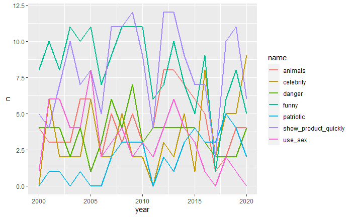

```r
sb %>%
  pivot_longer(cols = funny:use_sex) %>%
  select(year, brand, name, value) %>%
  group_by(year, name) %>%
  summarize(n = sum(value)) %>%
  ggplot() +
  geom_line(aes(x = year, y = n, group = name, color = name), size = 1)
```

The same idea but a bump chart:

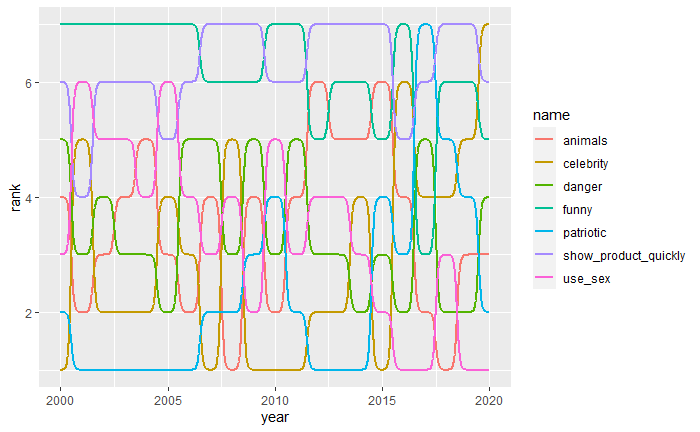

Sex seems like it’s pretty much out. Let me highlight that.

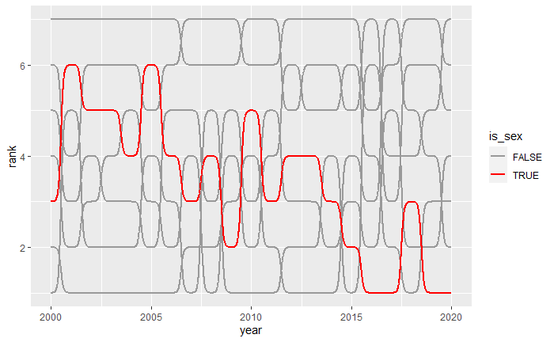

That’s a pretty clear trend, and a very good headline. “Sex is Out.” Neat.